# SECOND HOMEWORK: SUPERVISED LEARNING

### 5.2.2 Bayes classifiers.

### 5.2.3 Quadratic Discriminant Analysis.

First off, QDA will be applied. Quadratic Discriminant Analysis (QDA) is a generative model, which assumes that each class follow a Gaussian distribution. QDA, because it allows for more flexibility for the covariance matrix, tends to fit the data better than LDA (Linear Discriminant Analysis), but then it has more parameters to estimate. The number of parameters increases significantly with QDA, because, with QDA, you will have a separate covariance matrix for every class. If there are many classes and not so many sample points, this can be a problem.

```r
set.seed(123)
qda.model <- qda(satisfaction ~ ., data=PassengersTrain)
qda.model
```

```
## Call:
## qda(satisfaction ~ ., data = PassengersTrain)
##
## Prior probabilities of groups:
## dissatisfied    satisfied
##    0.5666043    0.4333957
##
## Group means:
##              GenderMale Customer.TypeLoyal Customer      Age
## dissatisfied  0.4888871                   0.7523720 37.60256
## satisfied     0.5006853                   0.8996368 41.75493
##              Type.of.TravelPersonal Travel  ClassEco ClassEco Plus
## dissatisfied                    0.49085286 0.6473502    0.09487865
## satisfied                       0.07147752 0.1926741    0.04146107
##              Flight.Distance Inflight.wifi.service
## dissatisfied        930.6878              2.401504
## satisfied          1524.5223              3.156181
##              Departure.Arrival.time.convenient Ease.of.Online.booking
## dissatisfied                          3.127772               2.547806
## satisfied                             2.963713               3.033066
##              Gate.location Food.and.drink Online.boarding Seat.comfort
## dissatisfied      2.978430       2.957278        2.656104     3.035697
## satisfied         2.973136       3.521587        4.027447     3.972074
##              Inflight.entertainment On.board.service Leg.room.service
## dissatisfied               2.890418         3.022042         2.997851
## satisfied                  3.960184         3.856462         3.817743
##              Baggage.handling Checkin.service Inflight.service Cleanliness
## dissatisfied         3.374089        3.043036         3.386670    2.933585
## satisfied            3.963473        3.653098         3.974952    3.743969
##              Departure.Delay.in.Minutes Arrival.Delay.in.Minutes
## dissatisfied                   16.51140                 17.18313
## satisfied                      12.54924                 12.64583
```

Once the model is fit, it is time to check if it is a valid one or not. This will be tested on the testing dataset using the function ‘predict’.

```r
prediction = predict(qda.model, newdata=PassengersTest)$class
```

Finally, it is time to check the effectiveness of our model using the confusion matrix (check above for further explanations).

```r
qda_results <- confusionMatrix(prediction, PassengersTest$satisfaction)
qda_results
```

```
## Confusion Matrix and Statistics
##
##               Reference
## Prediction     dissatisfied satisfied
##   dissatisfied        18365      3123
##   satisfied            2178     12590
##
##                Accuracy : 0.8538
##                  95% CI : (0.8501, 0.8574)
##     No Information Rate : 0.5666
##     P-Value [Acc > NIR] : < 2.2e-16
##
##                   Kappa : 0.7002
##
##  Mcnemar's Test P-Value : < 2.2e-16
##
##             Sensitivity : 0.8940
##             Specificity : 0.8012
##          Pos Pred Value : 0.8547
##          Neg Pred Value : 0.8525
##              Prevalence : 0.5666
##          Detection Rate : 0.5065
##    Detection Prevalence : 0.5927
##       Balanced Accuracy : 0.8476
##
##        'Positive' Class : dissatisfied
##
```

As demonstrated, the model done with QDA seems to be a good prediction model, even though not better than the one obtained with penalized logistic regression. This can be highlighted since the accuracy obtained is of 0.8538. However, let’s check if using LDA better performance can be obtained.

## 5.3 LDA.

```r
lda.model <- lda(satisfaction ~ ., data=PassengersTrain)
lda.model
```

```
## Call:
## lda(satisfaction ~ ., data = PassengersTrain)
##
## Prior probabilities of groups:
## dissatisfied    satisfied
##    0.5666043    0.4333957
##
## Group means:
##              GenderMale Customer.TypeLoyal Customer      Age
## dissatisfied  0.4888871                   0.7523720 37.60256
## satisfied     0.5006853                   0.8996368 41.75493
##              Type.of.TravelPersonal Travel  ClassEco ClassEco Plus
## dissatisfied                    0.49085286 0.6473502    0.09487865
## satisfied                       0.07147752 0.1926741    0.04146107
##              Flight.Distance Inflight.wifi.service
## dissatisfied        930.6878              2.401504
## satisfied          1524.5223              3.156181
##              Departure.Arrival.time.convenient Ease.of.Online.booking
## dissatisfied                          3.127772               2.547806
## satisfied                             2.963713               3.033066
##              Gate.location Food.and.drink Online.boarding Seat.comfort
## dissatisfied      2.978430       2.957278        2.656104     3.035697
## satisfied         2.973136       3.521587        4.027447     3.972074
##              Inflight.entertainment On.board.service Leg.room.service
## dissatisfied               2.890418         3.022042         2.997851
## satisfied                  3.960184         3.856462         3.817743
##              Baggage.handling Checkin.service Inflight.service Cleanliness
## dissatisfied         3.374089        3.043036         3.386670    2.933585
## satisfied            3.963473        3.653098         3.974952    3.743969
##              Departure.Delay.in.Minutes Arrival.Delay.in.Minutes
## dissatisfied                   16.51140                 17.18313
## satisfied                      12.54924                 12.64583
##
## Coefficients of linear discriminants:
##                                             LD1
## GenderMale                         3.129434e-02
## Customer.TypeLoyal Customer        1.265758e+00
## Age                               -4.151696e-03
## Type.of.TravelPersonal Travel     -1.563632e+00
## ClassEco                          -5.163510e-01
## ClassEco Plus                     -5.471607e-01
## Flight.Distance                    1.313955e-06
## Inflight.wifi.service              2.708784e-01
## Departure.Arrival.time.convenient -6.610263e-02
## Ease.of.Online.booking            -1.663226e-01
## Gate.location                      1.721132e-02
## Food.and.drink                    -2.335301e-02
## Online.boarding                    3.212918e-01
## Seat.comfort                       3.398037e-02
## Inflight.entertainment             6.354839e-02
## On.board.service                   1.367706e-01
## Leg.room.service                   1.298224e-01
## Baggage.handling                   6.493737e-02
## Checkin.service                    1.538060e-01
## Inflight.service                   6.853327e-02
## Cleanliness                        1.058686e-01
## Departure.Delay.in.Minutes         2.070776e-03
## Arrival.Delay.in.Minutes          -4.210522e-03
```

Once the model is fit, it is time to check if it is a valid one or not. This will be tested on the testing dataset using the function ‘predict’.

```r
prediction = predict(lda.model, newdata=PassengersTest)$class
```

Finally, it is time to check the effectiveness of our model using the confusion matrix (check above for further explanations).

```r
lda_results <- confusionMatrix(prediction, PassengersTest$satisfaction)
lda_results
```

```
## Confusion Matrix and Statistics
##
##               Reference
## Prediction     dissatisfied satisfied
##   dissatisfied        18518      2624
##   satisfied            2025     13089
##
##                Accuracy : 0.8718
##                  95% CI : (0.8683, 0.8752)
##     No Information Rate : 0.5666
##     P-Value [Acc > NIR] : < 2.2e-16
##
##                   Kappa : 0.7377
##
##  Mcnemar's Test P-Value : < 2.2e-16
##
##             Sensitivity : 0.9014
##             Specificity : 0.8330
##          Pos Pred Value : 0.8759
##          Neg Pred Value : 0.8660
##              Prevalence : 0.5666
##          Detection Rate : 0.5108
##    Detection Prevalence : 0.5831
##       Balanced Accuracy : 0.8672
##
##        'Positive' Class : dissatisfied
##
```

The result of LDA can awe us, since it is known that QDA tends to fit better the data. Nonetheless, as it has been disproved above, in this case the model obtained using LDA obtained a slight better accuracy (0.8718).

### 5.3.1 A benchmark model.

In order to finish the statistical classification, it can be interesting to compare our results with a benchmark model. Benchmarking is the process of comparing your result to existing methods. In this case, what will be the accuracy on a benchmark model that predicts the most frequent outcome for all observations?

```r
# First off, let's check which is the most frequent outcome.
table(PassengersTrain$satisfaction) # ergo, the most frequent outcome is dissatisfied.
```

```
##
## dissatisfied    satisfied
##        38154        29184
```

```r
# Now, let's obtain the accuracy of this model.
obs <- max(table(PassengersTest$satisfaction))
benchmark <- obs/nrow(PassengersTest)
benchmark
```

```
## [1] 0.5666097
```

Note the benchmark is not so bad. However, this model is not the most efficient one in terms of performance measurements. In comparison with the other methods applied above (Penalized logistic regression (accuracy: 0.8735), QDA (accuracy: 0.8538) and LDA (accuracy: 0.8718), it is very clear that Penalized logistic regression seemed to be the most efficient method.

## 5.4 Machine-learning classification.

A machine learning model is a file that has been trained to recognize certain types of patterns. We train a model over a set of data, providing it an algorithm that it can use to reason over and learn from those data. For now, let’s try decision trees and random forests and check out which are the outputs and predictions of our models.

### 5.4.1 Decision trees

Decision trees are a decision support tool that uses a tree-like model of decisions and their possible consequences. Nonetheless, before starting, one must be aware of both advantages and disadvantages of this method.

```
- Advantages:
  1. Requires less effort for data preparation and pre-processing.
  2. Very intuitive and easy to explain.

- Disadvantages:
  1. A small change in the data can cause a large change in the structure.
  2. Decision trees often involve higher time to train the model.
```

The very first step is to choose the hyper-parameters. Note that many models contain parameters that cannot be learned from the training data and therefore must be set by us. These are known as hyperparameters. The results of a model can depend to a great extent on the value that its hyperparameters take, yet it is not possible to know in advance which is the appropriate one. The most common way to find optimal values is by trying different possibilities. Hence, the best combination of hyperparameters is selected by trying several combinations and comparing the accuracy, precision and specificity.

There are many important hyperparameters, along the lines of:

```
1. minsplit: minimum number of observations in a node before before a split.
2. maxdepth: maximum depth of any node of the final tree.
3. cp; degree of complexity, the smaller the more branches.
```

```r
set.seed(123)
# In this case, the process will start with some random values: minsplit = 30,
# maxdepth = 10, and cp = 0.01.
control = rpart.control(minsplit = 30, maxdepth = 10, cp=0.01)

# Then, the model is created using the function 'rpart()'. Rpart is a powerful
# machine learning library in R that is used for building classification and
# regression trees. This library implements recursive partitioning and is very
# easy to use. It contains:
#     1. formula: in this case, it refers to the dependent variable. It is
#        satisfaction~. because it is desired to predict the variable satisfaction
#        with respect to the rest of the variables in the dataset.
#     2. data: an optional data frame in which to interpret the variables named
#        in the formula; it will be the training dataset.
#     3. method: if the dependent variable is a factor, method = 'class'.
#     4. control: used to specify the hyperparameters.

dtFit <- rpart(satisfaction ~., data=PassengersTrain, method = "class", control = control)
summary(dtFit)
```

```
## Call:
## rpart(formula = satisfaction ~ ., data = PassengersTrain, method = "class",
##     control = control)
##   n= 67338
##
##           CP nsplit rel error    xerror        xstd
## 1 0.51141036      0 1.0000000 1.0000000 0.004406234
## 2 0.12966009      1 0.4885896 0.4885896 0.003632712
## 3 0.03981634      2 0.3589296 0.3589296 0.003222678
## 4 0.03018777      3 0.3191132 0.3191132 0.003069569
## 5 0.02463679      4 0.2889254 0.2889254 0.002942864
## 6 0.01003975      5 0.2642887 0.2642887 0.002831724
## 7 0.01000000      8 0.2341694 0.2472245 0.002750195
##
## Variable importance
##        Online.boarding  Inflight.wifi.service           Seat.comfort
##                     26                     21                     12
## Ease.of.Online.booking Inflight.entertainment                  Class
##                     10                     10                      9
##         Type.of.Travel        Checkin.service                    Age
##                      9                      1                      1
##            Cleanliness       Inflight.service
##                      1                      1
##
## Node number 1: 67338 observations,    complexity param=0.5114104
##   predicted class=dissatisfied  expected loss=0.4333957  P(node) =1
##     class counts: 38154 29184
##    probabilities: 0.567 0.433
##   left son=2 (33895 obs) right son=3 (33443 obs)
##   Primary splits:
##       Online.boarding        < 3.5  to the left,  improve=11155.580, (0 missing)
##       Class                  splits as  RLL,      improve= 8402.532, (0 missing)
##       Type.of.Travel         splits as  RL,       improve= 6688.254, (0 missing)
##       Inflight.entertainment < 3.5  to the left,  improve= 5728.240, (0 missing)
##       Inflight.wifi.service  < 3.5  to the left,  improve= 5496.122, (0 missing)
##   Surrogate splits:
##       Seat.comfort           < 3.5  to the left,  agree=0.731, adj=0.458, (0 split)
##       Inflight.wifi.service  < 3.5  to the left,  agree=0.713, adj=0.423, (0 split)
##       Ease.of.Online.booking < 3.5  to the left,  agree=0.675, adj=0.345, (0 split)
##       Class                  splits as  RLL,      agree=0.672, adj=0.339, (0 split)
```

[output cut: 143 more lines]

```
##
## Node number 29: 1978 observations
##   predicted class=satisfied     expected loss=0.05005056  P(node) =0.0293742
##     class counts:    99  1879
##    probabilities: 0.050 0.950
##
## Node number 56: 1235 observations
##   predicted class=dissatisfied  expected loss=0.1441296  P(node) =0.01834031
##     class counts:  1057   178
##    probabilities: 0.856 0.144
##
## Node number 57: 3363 observations
##   predicted class=satisfied     expected loss=0.4029141  P(node) =0.04994208
##     class counts:  1355  2008
##    probabilities: 0.403 0.597
```

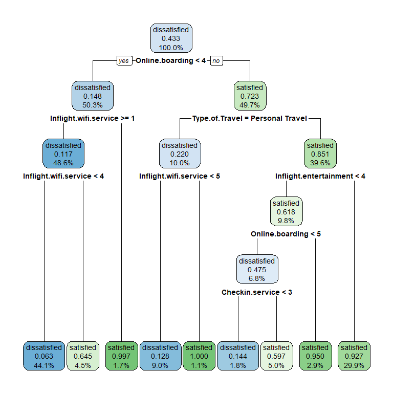

```r
# Once the model is done, it is key to visualize it:
rpart.plot(dtFit, digits=3)
```

Being this the first version of our decision tree, an interpretation is a must to understand this output. If we were to start analyzing from the beginning, one could tell that a key variable is ‘Online.boarding’. One could say that this a prime factor in the satisfaction, as well as ‘Inflight.wifi.service’ and ‘Type.of.travel’.

On the one hand, let’s analyze the case in which the values of online boarding are less than 4. This case leads to more than half of passengers being dissatisfied. This is comprehensive, since we all know how stressing getting tickets can be. When traveling, we need nothing but being comfortable, and if no processes like online boarding are available, it could lead to a bad mood. However, something that is not a surprise to us is how the bad quality of inflight wifi service influence almost all the satisfaction.

Finally, it is time to predict our model and check the effectiveness using the confusion matrix (check above for further explanations).

```r
dtPred <- predict(dtFit, PassengersTest, type = "class")
dt_option1_results <- confusionMatrix(factor(dtPred), PassengersTest$satisfaction)
dt_option1_results
```

```
## Confusion Matrix and Statistics
##
##               Reference
## Prediction     dissatisfied satisfied
##   dissatisfied        18370      1643
##   satisfied            2173     14070
##
##                Accuracy : 0.8947
##                  95% CI : (0.8915, 0.8979)
##     No Information Rate : 0.5666
##     P-Value [Acc > NIR] : < 2.2e-16
##
##                   Kappa : 0.7865
##
##  Mcnemar's Test P-Value : < 2.2e-16
##
##             Sensitivity : 0.8942
##             Specificity : 0.8954
##          Pos Pred Value : 0.9179
##          Neg Pred Value : 0.8662
##              Prevalence : 0.5666
##          Detection Rate : 0.5067
##    Detection Prevalence : 0.5520
##       Balanced Accuracy : 0.8948
##
##        'Positive' Class : dissatisfied
##
```

As checked, the following performance measures were obtained: accuracy = 0.8947, sensitivity = 0.8942, specificity = 0.8954. It looks as though a good model was obtained. Nonetheless, hyperparameters play an important role and, as stated above, trying different combinations can lead to better outcomes.

```r
set.seed(123)
caret.fit <- train(satisfaction~.,
                   data = PassengersTrain,
                   method = "rpart",
                   control=rpart.control(minsplit = 40, maxdepth = 12),
                   trControl = trainControl(method = "cv", number = 5),
                   tuneLength=10)
```

Finally, it is time to predict our model and check the effectiveness using the confusion matrix (check above for further explanations).

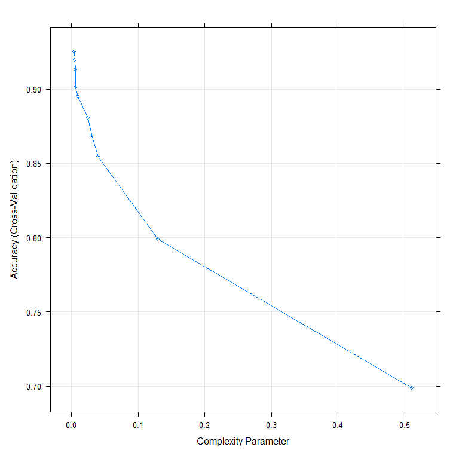

```r
plot(caret.fit)
```

```r
caret.fit$results
```

```
##             cp  Accuracy     Kappa  AccuracySD     KappaSD
## 1  0.004009046 0.9253914 0.8481629 0.001805447 0.003668475
## 2  0.005059850 0.9197629 0.8374256 0.004546643 0.008862439
## 3  0.005876508 0.9131245 0.8241603 0.007489055 0.015570453
## 4  0.006056401 0.9010958 0.7997171 0.006244081 0.012977658
## 5  0.010039748 0.8952449 0.7879644 0.005436505 0.010534366
## 6  0.024636787 0.8807213 0.7591601 0.006258031 0.013005181
## 7  0.030187774 0.8687073 0.7330542 0.007906256 0.017998160
## 8  0.039816338 0.8542573 0.7009898 0.010312601 0.021955080
## 9  0.129660088 0.7987908 0.5954861 0.025429151 0.047115706
## 10 0.511410362 0.6985235 0.3434254 0.120430501 0.313510643
```

```r
caret.fit
```

```
## CART
##
## 67338 samples
##    22 predictor
##     2 classes: 'dissatisfied', 'satisfied'
##
## No pre-processing
## Resampling: Cross-Validated (5 fold)
## Summary of sample sizes: 53870, 53870, 53870, 53872, 53870
## Resampling results across tuning parameters:
##
##   cp           Accuracy   Kappa
##   0.004009046  0.9253914  0.8481629
##   0.005059850  0.9197629  0.8374256
##   0.005876508  0.9131245  0.8241603
##   0.006056401  0.9010958  0.7997171
##   0.010039748  0.8952449  0.7879644
##   0.024636787  0.8807213  0.7591601
##   0.030187774  0.8687073  0.7330542
##   0.039816338  0.8542573  0.7009898
##   0.129660088  0.7987908  0.5954861
##   0.511410362  0.6985235  0.3434254
##
## Accuracy was used to select the optimal model using the largest value.
## The final value used for the model was cp = 0.004009046.
```

As checked, the following performance measures were obtained: with a cp of 0.004009046, the best model is obtained with an accuracy = 0.9253914. But observing the graph of the Accuracy vs. Complexity Parameter, it can be said that the greater the complexity parameter, the lower the accuracy.

Now, let’s observe the predictions:

```r
dt_pred <- predict(caret.fit, PassengersTest)
dt_option2_results <- confusionMatrix(factor(dt_pred), PassengersTest$satisfaction)
dt_option2_results
```

```
## Confusion Matrix and Statistics
##
##               Reference
## Prediction     dissatisfied satisfied
##   dissatisfied        19158      1431
##   satisfied            1385     14282
##
##                Accuracy : 0.9223
##                  95% CI : (0.9195, 0.9251)
##     No Information Rate : 0.5666
##     P-Value [Acc > NIR] : <2e-16
##
##                   Kappa : 0.8418
##
##  Mcnemar's Test P-Value : 0.3964
##
##             Sensitivity : 0.9326
##             Specificity : 0.9089
##          Pos Pred Value : 0.9305
##          Neg Pred Value : 0.9116
##              Prevalence : 0.5666
##          Detection Rate : 0.5284
##    Detection Prevalence : 0.5679
##       Balanced Accuracy : 0.9208
##
##        'Positive' Class : dissatisfied
##
```

It looks as though a good model was obtained with an accuracy = 0.9223, sensitivity = 0.9326 and specificity = 0.9089. Nonetheless, lets analyze what changes were made so that this hyperparameters led to a better model.

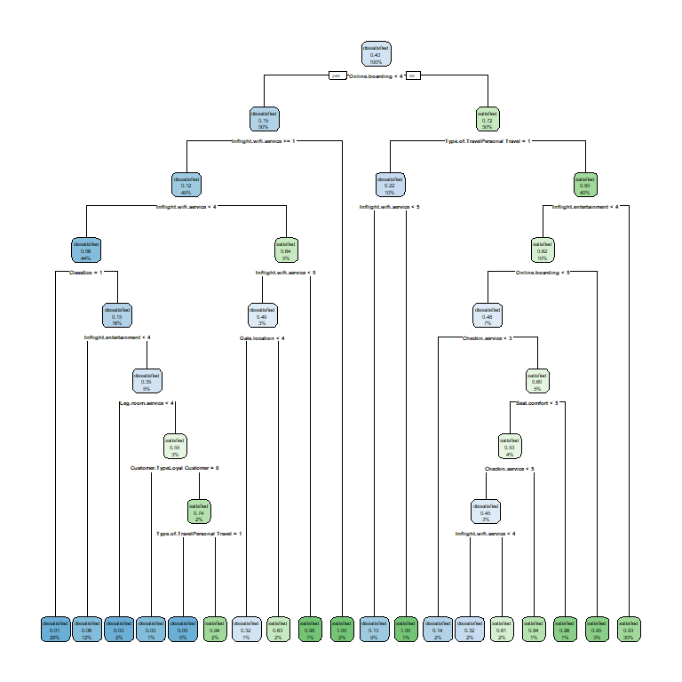

```r
rpart.plot(caret.fit$finalModel)
```

### 5.4.2 Random forests.

Random forests are a classification algorithm consisting of many decisions trees. It uses bagging and feature randomness when building each individual tree to try to create an uncorrelated forest of trees whose prediction by committee is more accurate than that of any individual tree. After everything, it has some advantages and, unfortunately, some disadvantages too:

```
- Advantages:
  1. Reduces overfitting in decision trees and helps improve the accuracy.
  2. Works well with categorical and continuous value.

- Disadvantages:
  1. Requires much computational power.
  2. Requires much time for training as it combines a lot of decision trees to
  determine the class.
```

```r
set.seed(123)
# The model is created using the function 'randomForest()'. It implements Breiman's
# random forest algorithm (based on Breiman and Cutler's original Fortran code)
# for classification and regression. It contains important fields like:
#     1. formula: in this case, it refers to the dependent variable. It is
#        satisfaction~. because it is desired to predict the variable satisfaction
#        with respect to the rest of the variables in the dataset.
#     2. data: an optional data frame in which to interpret the variables named
#        in the formula; it will be the training dataset.
#     3. mree: set to 200.
#     4. mtry: set to 10.

rf.train <- randomForest(satisfaction ~., data=PassengersTrain, ntree=200, mtry=10, importance=TRUE, do.trace=T)
```

```
## ntree      OOB      1      2
##     1:   5.88%  5.20%  6.76%
##     2:   5.98%  5.10%  7.12%
##     3:   5.85%  4.75%  7.29%
##     4:   5.72%  4.53%  7.28%
##     5:   5.65%  4.50%  7.16%
##     6:   5.48%  4.26%  7.08%
##     7:   5.33%  4.13%  6.89%
##     8:   5.15%  3.90%  6.79%
##     9:   5.03%  3.79%  6.65%
##    10:   4.89%  3.66%  6.50%
##    11:   4.88%  3.63%  6.51%
##    12:   4.70%  3.45%  6.33%
##    13:   4.68%  3.42%  6.34%
##    14:   4.62%  3.35%  6.28%
```

[output cut: 186 more lines]

```r
# Finally, it is time to predict our model and check the effectiveness
# using the confusion matrix (check above for further explanations).
rf.pred <- predict(rf.train, PassengersTest)
rf_option1_results <- confusionMatrix(factor(rf.pred), PassengersTest$satisfaction)
rf_option1_results
```

```
## Confusion Matrix and Statistics
##
##               Reference
## Prediction     dissatisfied satisfied
##   dissatisfied        20162       991
##   satisfied             381     14722
##
##                Accuracy : 0.9622
##                  95% CI : (0.9601, 0.9641)
##     No Information Rate : 0.5666
##     P-Value [Acc > NIR] : < 2.2e-16
##
##                   Kappa : 0.9226
##
##  Mcnemar's Test P-Value : < 2.2e-16
##
##             Sensitivity : 0.9815
##             Specificity : 0.9369
##          Pos Pred Value : 0.9532
##          Neg Pred Value : 0.9748
##              Prevalence : 0.5666
##          Detection Rate : 0.5561
##    Detection Prevalence : 0.5834
##       Balanced Accuracy : 0.9592
##
##        'Positive' Class : dissatisfied
##
```

As checked, the following performance measures were obtained: accuracy = 0.9622, sensitivity = 0.9815, specificity = 0.9369. At very first sight, one may think that it represents a good model with outstanding results. In hindsight, a high accuracy measured on the training set may be a result of overfitting. In fact, an accuracy measure of anything between 70%-90% is not only ideal, it’s realistic. However, because the values exposed above are greater than 90%, it may lead to some doubts about the method used.Let’s try another model with different hyperparameters.

Option 2: let’s switch the hyperparameters.

```r
set.seed(123)
# Let's obtain a new model changing the hyperparameters.
rf.train <- train(satisfaction ~.,
                  method = "rf",
                  data = PassengersTrain,
                  preProcess = c("center", "scale"),
                  ntree = 200,
                  tuneGrid = expand.grid(mtry=c(6,8,10)),
                  trControl = trainControl(method = "cv", number = 5))

# Finally, it is time to predict our model and  check the effectiveness using
# the confusion matrix (check above for further explanations).
rf.train$results
```

```
##   mtry  Accuracy     Kappa   AccuracySD      KappaSD
## 1    6 0.9618789 0.9221202 0.0008287960 0.0017009757
## 2    8 0.9623244 0.9230219 0.0004268772 0.0008602583
## 3   10 0.9624729 0.9233348 0.0006099153 0.0012288591
```

```r
rf.train
```

```
## Random Forest
##
## 67338 samples
##    22 predictor
##     2 classes: 'dissatisfied', 'satisfied'
##
## Pre-processing: centered (23), scaled (23)
## Resampling: Cross-Validated (5 fold)
## Summary of sample sizes: 53870, 53870, 53870, 53872, 53870
## Resampling results across tuning parameters:
##
##   mtry  Accuracy   Kappa
##    6    0.9618789  0.9221202
##    8    0.9623244  0.9230219
##   10    0.9624729  0.9233348
##
## Accuracy was used to select the optimal model using the largest value.
## The final value used for the model was mtry = 10.
```

As checked, the following performance measures were obtained: with mtry = 10, the best model is obtained with an accuracy = 0.9624729. Now, let’s observe the predictions:

```r
rfPred = predict(rf.train, newdata=PassengersTest)
rf_option2_results <- confusionMatrix(factor(rfPred), PassengersTest$satisfaction)
rf_option2_results
```

```
## Confusion Matrix and Statistics
##
##               Reference
## Prediction     dissatisfied satisfied
##   dissatisfied        20147       996
##   satisfied             396     14717
##
##                Accuracy : 0.9616
##                  95% CI : (0.9596, 0.9636)
##     No Information Rate : 0.5666
##     P-Value [Acc > NIR] : < 2.2e-16
##
##                   Kappa : 0.9215
##
##  Mcnemar's Test P-Value : < 2.2e-16
##
##             Sensitivity : 0.9807
##             Specificity : 0.9366
##          Pos Pred Value : 0.9529
##          Neg Pred Value : 0.9738
##              Prevalence : 0.5666
##          Detection Rate : 0.5557
##    Detection Prevalence : 0.5832
##       Balanced Accuracy : 0.9587
##
##        'Positive' Class : dissatisfied
##
```

## 5.5 Conclusions about classification.

Once several methods have been applied to predict the chosen categorical variable (‘satisfaction’), it is time to summarize the classification part and continue with the rest. For this, to give a little rundown of all the models performed above, let’s observe the code below.

```r
results <- rbind(c("BENCHMARK", benchmark),
                 c("PENALIZED LOGISTIC REGRESSION:", plr_results$overall[1]),
                 c("QDA", qda_results$overall[1]),
                 c("LDA", lda_results$overall[1]),
                 c("DECISION TREES (OPTION 1)", dt_option1_results$overall[1]),
                 c("DECISION TREES (OPTION 2)", dt_option2_results$overall[1]),
                 c("RANDOM FORESTS TREES (OPTION 1)", rf_option1_results$overall[1]),
                 c("RANDOM FORESTS (OPTION 2)",rf_option2_results$overall[1]))
results
```

```
##                                        Accuracy
## [1,] "BENCHMARK"                       "0.566609664607237"
## [2,] "PENALIZED LOGISTIC REGRESSION:"  "0.873538172992056"
## [3,] "QDA"                             "0.853789717563989"
## [4,] "LDA"                             "0.871772947925861"
## [5,] "DECISION TREES (OPTION 1)"       "0.894748455428067"
## [6,] "DECISION TREES (OPTION 2)"       "0.922330097087379"
## [7,] "RANDOM FORESTS TREES (OPTION 1)" "0.962157987643425"
## [8,] "RANDOM FORESTS (OPTION 2)"       "0.961606354810238"
```

During this portion of the project, there are lots of models. Nonetheless, it is of high vitality to always consider the “No-Free-Lunch-Theorem”, which states that there is no best algorithm that works best in all cases. Because of this, it is in us to whether or not consider a model good enough. In addition, each model has its limitations.

As observed in the results from above, several model were contemplated in the prediction of the variable ‘satisfaction’, all the way from a simple benchmark model to a complex, long and CPU-consuming random forest. It looks as though all the models show very good results, better than expected. Nonetheless, the best model ended up being a random forest. Moreover, as stated earlier, it is of high vitality to comment on the fact that an accuracy of 0.9622 was obtained.

It is known that ‘extremely’ high values of accuracy are not a good sign, or are not always a good sign, meaning that something wrong could have been done. Howbeit, what if we take a further look at out categorical variable: it measures the satisfaction of certain clients, consisting of 0 and 1. Now if we realize, all the high accuracies are not wrong, these simply mean that our categorical variable is so easy to predict, that any advanced model with good hyperparameters could predict almost perfectly the outcomes.

Before finishing, it will be interesting to analyze how expensive the chosen method (Random forests) will be in case this was the main goal of a company. Because there is no such cost variable to use from the dataset, it is possible to set our own values.

Cost matrix:

| Prediction/Reference | no | yes |
| --- | --- | --- |
| predicted no | 0 | 500 |
| predicted yes | 100 | 140 |

Unit cost is then: 0*TN + 100*FP + 500*FN + 140*TP

```r
cost.unit <- c(0, 100, 500, 140)
cost_rf = sum(as.vector(rf_option1_results$table)*cost.unit)/sum(rf_option1_results$table)
cost_rf
```

```
## [1] 71.56553
```

# 6 Regression

Regression, one of the most common types of machine learning models, estimates the relationships between variables. Whereas classification models identify which category an observation belongs to, regression models estimate a numeric value.

Note that for this part, as stated in the introduction of the homework, a numerical variable has to be chosen. However, it is not logic to choose a variable randomly; that is, there must be some goals or objectives, and then check which variable is the most useful one.

What is it desired to predict? Why? In my case, I desire to predict the variable “Departure.Arrival.time.convenient”. The main reason why I choose this variable to be my target variable is because I do certainly believe that it could be exciting to predict how convenient the departure and arrival times seem to be for passengers. It may be obvious that this is a goal that could be answered by saying: some passengers think it is more convenient to fly in the morning and others in the afternoon. However, it is of high curiosity to know if this is irrelevant and if what really matters is the other aspects of a flight.

## 6.1 Model selection.

Before starting, it is key to understand that no methods can still be applied, since a previous step needs to be done. Before you begin the regression analysis, you should review the dataset to develop an understanding of the relevant variables, their relationships, and the expected coefficient signs and effect magnitudes. That is, the strong objective is to identify the subset of the p variables that is really associated to the response.

To determine whether the selected model is good or not, there are some quality measures along the lines of Adjusted R-Squared, Akaike information criterion (AIC), Bayesian information criterion (BIC)…

From the list of methods that can be applied to estimate the best model, the one that should be chosen should be subset selection. Best subset selection is a method that aims to find the subset of independent variables (Xi) that best predict the outcome (Y) and it does so by considering all possible combinations of independent variables.

Nonetheless, due to the extensiveness of the dataset, another method is followed: stepwise selection. Stepwise regression is the step-by-step iterative construction of a regression model that involves the selection of independent variables to be used in a final model. It involves adding or removing potential explanatory variables in succession and testing for statistical significance after each iteration.

```
1. Begins with a model that contains no variables (called the Null Model).
2. Then starts adding the most significant variables one after the other.
3. Until a pre-specified stopping rule is reached or until all the variables
under consideration are included in the model.
```

Here’s an example of forward selection with 5 variables:

[figure not shown]

### 6.1.1 Stepwise selection.

As stated above, the selected target variable is “Departure.Arrival.time.Convenient”. Let’s try this model and see if by combining almost all the variables in the dataset, a good outcome can be obtained.

```r
set.seed(123)
# In order to test the model, the function 'lm()' is used. It fits linear models
# and has some fields like:
#     - formula: a symbolic description of the model to be fitted.
#     - data: an optional data frame, list or environment containing the variables in the model.

linFit <- lm(Departure.Arrival.time.convenient ~ Age + Flight.Distance + Inflight.wifi.service +
               Ease.of.Online.booking + Gate.location + Food.and.drink + Online.boarding + Seat.comfort +
               Inflight.entertainment + On.board.service + Leg.room.service + Baggage.handling + Checkin.service +
               Inflight.service + Cleanliness + Departure.Delay.in.Minutes + Arrival.Delay.in.Minutes,
             data=PassengersTrain)
summary(linFit)
```

```
##
## Call:
## lm(formula = Departure.Arrival.time.convenient ~ Age + Flight.Distance +
##     Inflight.wifi.service + Ease.of.Online.booking + Gate.location +
##     Food.and.drink + Online.boarding + Seat.comfort + Inflight.entertainment +
##     On.board.service + Leg.room.service + Baggage.handling +
##     Checkin.service + Inflight.service + Cleanliness + Departure.Delay.in.Minutes +
##     Arrival.Delay.in.Minutes, data = PassengersTrain)
##
## Residuals:
##     Min      1Q  Median      3Q     Max
## -5.5490 -0.6295  0.0093  0.7242  4.8101
##
## Coefficients:
##                              Estimate Std. Error t value Pr(>|t|)
## (Intercept)                 3.224e-01  3.028e-02  10.646  < 2e-16 ***
## Age                         6.356e-03  3.398e-04  18.706  < 2e-16 ***
## Flight.Distance            -3.818e-05  5.145e-06  -7.421 1.18e-13 ***
## Inflight.wifi.service       1.117e-01  5.698e-03  19.606  < 2e-16 ***
## Ease.of.Online.booking      3.163e-01  5.559e-03  56.906  < 2e-16 ***
## Gate.location               3.415e-01  4.486e-03  76.132  < 2e-16 ***
## Food.and.drink              3.163e-02  5.436e-03   5.818 5.97e-09 ***
## Online.boarding            -1.563e-01  4.959e-03 -31.521  < 2e-16 ***
## Seat.comfort                5.761e-02  5.747e-03  10.025  < 2e-16 ***
## Inflight.entertainment     -1.932e-01  7.140e-03 -27.054  < 2e-16 ***
## On.board.service            8.627e-02  5.035e-03  17.133  < 2e-16 ***
## Leg.room.service           -6.393e-02  4.251e-03 -15.039  < 2e-16 ***
## Baggage.handling            5.246e-02  5.700e-03   9.205  < 2e-16 ***
## Checkin.service             1.000e-01  4.260e-03  23.473  < 2e-16 ***
## Inflight.service            7.557e-02  6.000e-03  12.595  < 2e-16 ***
## Cleanliness                 9.582e-02  6.319e-03  15.165  < 2e-16 ***
## Departure.Delay.in.Minutes  1.035e-04  4.998e-04   0.207    0.836
## Arrival.Delay.in.Minutes    1.188e-04  4.927e-04   0.241    0.809
## ---
## Signif. codes:  0 '***' 0.001 '**' 0.01 '*' 0.05 '.' 0.1 ' ' 1
##
## Residual standard error: 1.275 on 67320 degrees of freedom
## Multiple R-squared:  0.3017, Adjusted R-squared:  0.3015
## F-statistic:  1711 on 17 and 67320 DF,  p-value: < 2.2e-16
```

Somehow a bad model. Why? Some theoretical background is needed. The adjusted R-squared is a modified version of R-squared that adjusts for predictors that are not significant in a regression model. Compared to a model with additional input variables, a lower adjusted R-squared indicates that the additional input variables are not adding value to the model; and a higher adjusted R-squared indicates that the additional input variables are adding value to the model. By the results seen in the function ‘summary()’, the adjusted R-squared is 0.3015. Hence, from my point of view, it is better to restructure this part of the project. By this it is meant that the target variable that was thought to be good, it ended up being not, since a bad R-squared value is obtained using almost all the variables.

```r
set.seed(123)
# Let's change our categorical variable to "Departure.Delay.in.Minutes":
linFit <- lm(Departure.Delay.in.Minutes ~ Age + Flight.Distance + Inflight.wifi.service +
               Ease.of.Online.booking + Gate.location + Food.and.drink + Online.boarding + Seat.comfort +
               Inflight.entertainment + On.board.service + Leg.room.service + Baggage.handling + Checkin.service +
               Inflight.service + Cleanliness + Departure.Arrival.time.convenient + Arrival.Delay.in.Minutes,
             data=PassengersTrain)
summary(linFit)
```

```
##
## Call:
## lm(formula = Departure.Delay.in.Minutes ~ Age + Flight.Distance +
##     Inflight.wifi.service + Ease.of.Online.booking + Gate.location +
##     Food.and.drink + Online.boarding + Seat.comfort + Inflight.entertainment +
##     On.board.service + Leg.room.service + Baggage.handling +
##     Checkin.service + Inflight.service + Cleanliness + Departure.Arrival.time.convenient +
##     Arrival.Delay.in.Minutes, data = PassengersTrain)
##
## Residuals:
##      Min       1Q   Median       3Q      Max
## -193.293   -0.663   -0.257    2.071   85.466
##
## Coefficients:
##                                     Estimate Std. Error t value Pr(>|t|)
## (Intercept)                       -7.093e-01  2.337e-01  -3.035  0.00241 **
## Age                                9.754e-04  2.627e-03   0.371  0.71043
## Flight.Distance                    1.161e-04  3.969e-05   2.926  0.00344 **
## Inflight.wifi.service             -1.041e-02  4.407e-02  -0.236  0.81331
## Ease.of.Online.booking             2.944e-02  4.389e-02   0.671  0.50229
## Gate.location                      1.718e-02  3.605e-02   0.477  0.63364
## Food.and.drink                     8.422e-02  4.193e-02   2.009  0.04458 *
## Online.boarding                   -4.624e-03  3.853e-02  -0.120  0.90446
## Seat.comfort                       7.383e-03  4.435e-02   0.166  0.86780
## Inflight.entertainment            -1.170e-01  5.536e-02  -2.113  0.03464 *
## On.board.service                   2.609e-02  3.891e-02   0.670  0.50264
## Leg.room.service                   4.907e-02  3.284e-02   1.494  0.13508
## Baggage.handling                   5.060e-02  4.398e-02   1.150  0.24998
## Checkin.service                   -1.084e-02  3.299e-02  -0.329  0.74249
## Inflight.service                   7.806e-02  4.632e-02   1.685  0.09197 .
## Cleanliness                        4.357e-02  4.881e-02   0.893  0.37206
## Departure.Arrival.time.convenient  6.155e-03  2.972e-02   0.207  0.83594
## Arrival.Delay.in.Minutes           9.522e-01  9.854e-04 966.211  < 2e-16 ***
## ---
## Signif. codes:  0 '***' 0.001 '**' 0.01 '*' 0.05 '.' 0.1 ' ' 1
##
## Residual standard error: 9.833 on 67320 degrees of freedom
## Multiple R-squared:  0.9332, Adjusted R-squared:  0.9332
## F-statistic: 5.533e+04 on 17 and 67320 DF,  p-value: < 2.2e-16
```

Somehow a lot better. The value of the adjusted R-squared increased more than 0.6. Therefore, the new categorical variables seems a good choice. Let’s check how does the model behave under a stepwise AIC.

This is performed using the function “ols_step_both_aic()”. It is used to build a regression model from a set of candidate predictor variables by entering and removing predictors based on akaike information criteria, in a stepwise manner until there is no variable left to enter or remove any more.

```r
stepwise <- ols_step_both_aic(linFit)
stepwise
```

```
##
##
##                                              Stepwise Summary
## ---------------------------------------------------------------------------------------------------------
## Variable                     Method        AIC            RSS           Sum Sq        R-Sq      Adj. R-Sq
## ---------------------------------------------------------------------------------------------------------
## Arrival.Delay.in.Minutes    addition    498957.001    6512622.457    90949545.011    0.93318      0.93318
## Flight.Distance             addition    498946.935    6511455.579    90950711.889    0.93319      0.93319
## Inflight.service            addition    498939.970    6510588.780    90951578.688    0.93320      0.93320
## Food.and.drink              addition    498939.423    6510342.517    90951824.951    0.93320      0.93320
## Leg.room.service            addition    498939.258    6510133.131    90952034.337    0.93320      0.93320
## Inflight.entertainment      addition    498938.432    6509859.982    90952307.486    0.93321      0.93320
## ---------------------------------------------------------------------------------------------------------
```

```r
# Now it is time to try to make a prediction in the testing dataset.
predictions <- predict(linFit, newdata=PassengersTest)
cor(PassengersTest$Departure.Delay.in.Minutes, predictions)^2
```

```
## [1] 0.9302968
```

## 6.2 Regularization methods.

Regularization is a technique which makes slight modifications to the learning algorithm such that the model generalizes better. This in turn improves the model’s performance on the unseen data as well.

The models done above are completely fine but it is time to go further and try some more advanced methods with which better outputs could be obtained. Hence, let’s make models with statistical learning and machine learning and check the results. First off, let’s define some methods or variables that may be needed later on through the project.

```r
set.seed(123)
# To begin with, the function 'trainControl()' is used to choose the resampling method.
# The function trainControl generates parameters that further control how models
# are created, with important values like :
#     1. 'method': the resampling method. In this case, 'cv' was applied, which stands
#         for cross-validation (a statistical method of evaluating and comparing learning
#         algorithms by dividing data into two segments: one used to learn or train a model
#         and the other used to validate the model).
#     2. 'number': either the number of folds or the number of resampling iterations.
#         In this case, a 5-fold cross-validation is considered a good choice,
#         since it is considered to obtain pretty accurate results.

ctrl <- trainControl(method = "cv", number = 5,
                     classProbs = TRUE,
                     verboseIter=T)

# Secondly, let's state the model that will be used:
ModelS <- Departure.Delay.in.Minutes ~ Age + Flight.Distance + Inflight.wifi.service +
  Ease.of.Online.booking + Gate.location + Food.and.drink + Online.boarding + Seat.comfort +
  Inflight.entertainment + On.board.service + Leg.room.service + Baggage.handling + Checkin.service +
  Inflight.service + Cleanliness + Departure.Arrival.time.convenient + Arrival.Delay.in.Minutes

# Finally, as from now on we are going to try many models,it’s convenient to create
# a data frame with the predictor.
test_results <- data.frame(Departure.Delay.in.Minutes = PassengersTest$Departure.Delay.in.Minutes)
```

### 6.2.1 Linear regression.

The first method is linear regression. In statistics, linear regression is a linear approach for modelling the relationship between a scalar response and one or more explanatory variables. It is a very simple tool that has no bias but large variance in high dimension and provides good interpretation.

```r
# The first step is to train using the function "train()" from the caret package.
# It contains some remarkable fields:
#     1. 'form': A formula of the form y ~ x1 + x2 + ... Used to detail the
#        variable to be studied.
#     2. data: dataset used to make predictions.
#     3. 'method': a string specifying which classification or regression model
#        to use.
#     4. 'preProc': as its name says, it stands for "preProcessing". In this case,
#        it is stated to both scale and center the data. This is key in regression,
#        since it is often recommended to scale the features so that the predictors
#        have a mean of 0.
#     5. 'trControl': the resampling method.

lm_tune <- train(ModelS, data = PassengersTrain,
                 method = "lm",
                 preProc=c('scale', 'center'),
                 trControl = ctrl)
lm_tune
```

```
## Linear Regression
##
## 67338 samples
##    17 predictor
##
## Pre-processing: scaled (17), centered (17)
## Resampling: Cross-Validated (5 fold)
## Summary of sample sizes: 53870, 53871, 53870, 53870, 53871
## Resampling results:
##
##   RMSE      Rsquared  MAE
##   9.833635  0.93316   5.143978
##
## Tuning parameter 'intercept' was held constant at a value of TRUE
```

```r
test_results$lm <- predict(lm_tune, PassengersTest)
postResample(pred = test_results$lm,  obs = test_results$Departure.Delay.in.Minutes)
```

```
##       RMSE   Rsquared        MAE
## 10.0993303  0.9302968  5.1689970
```

Indeed, the same happens in the testing set, even getting worse results: 0.9302968.

### 6.2.2 Ridge regression

Ridge regression is a model tuning method that is used to analyse any data that suffers from multicollinearity. This method performs L2 regularization. When the issue of multicollinearity occurs, least-squares are unbiased, and variances are large, this results in predicted values being far away from the actual values.

```r
set.seed(123)
# Firt off, a grid for the hypertuning is defined.
ridge_grid <- expand.grid(lambda = seq(0, .1, length = 100))

# Then, the next step is to train using the function "train()" from the caret package.
# It contains some remarkable fields:
#     1. 'form': A formula of the form y ~ x1 + x2 + ... Used to detail the
#        variable to be studied. In this case, this information is stored in
#        ModelS previously defined.
#     2. data: dataset used to make predictions. As it is desired to train before
#        testing, the dataset partitioned beforehand is used (PassengersTrain)
#     3. 'method': a string specifying which classification or regression model
#        to use.
#     4. 'preProc': as its name says, it stands for "preProcessing". In this case,
#        it is stated to both scale and center the data. This is key in regression,
#        since it is often recommended to scale the features so that the predictors
#        have a mean of 0.
#     5. 'tuneGrid': By default, caret will estimate a tuning grid for each method.
#        However, sometimes the defaults are not the most sensible given the nature
#        of the data. The tuneGrid argument allows the user to specify a custom
#        grid of tuning parameters as opposed to simply using what exists implicitly.
#     6. 'trControl': the resampling method.
ridge_tune <- train(ModelS, data = PassengersTrain,
                    method='ridge',
                    preProc=c('scale','center'),
                    tuneGrid = ridge_grid,
                    trControl=ctrl)
```

Let’s check which was the value of lambda that performed the best:

```r
ridge_tune$bestTune
```

```
##   lambda
## 1      0
```

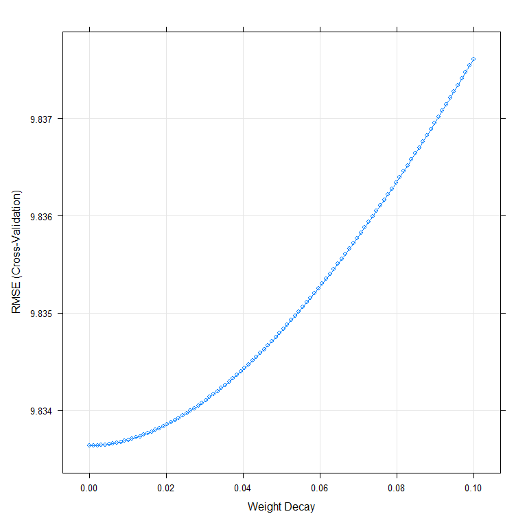

```r
plot(ridge_tune)
```

Indeed, the best tune is 0. Now it is time to predict on the testing set:

```r
test_results$ridge <- predict(ridge_tune, PassengersTest)
postResample(pred = test_results$ridge,  obs = test_results$Departure.Delay.in.Minutes)
```

```
##       RMSE   Rsquared        MAE
## 10.0993303  0.9302968  5.1689970
```

In this case, the value of 0.9302968 is obtained.

### 6.2.3 Lasso.

Lasso regression is a type of linear regression that uses shrinkage. Shrinkage is where data values are shrunk towards a central point, like the mean. The lasso procedure encourages simple, sparse models (i.e. models with fewer parameters). This particular type of regression is well-suited for models showing high levels of muticollinearity or when you want to automate certain parts of model selection, like variable selection/parameter elimination.

```r
set.seed(123)
# Firt off, a grid for the hypertuning is defined.
lasso_grid <- expand.grid(fraction = seq(.01, 1, length = 100))

# Moreover, the next step is to train using the function "train()" from the caret package.
# It contains some remarkable fields:
#     1. 'form': A formula of the form y ~ x1 + x2 + ... Used to detail the
#        variable to be studied. In this case, this information is stored in
#        ModelS previously defined.
#     2. data: dataset used to make predictions. As it is desired to train before
#        testing, the dataset partitioned beforehand is used (PassengersTrain)
#     3. 'method': a string specifying which classification or regression model
#        to use.
#     4. 'preProc': as its name says, it stands for "preProcessing". In this case,
#        it is stated to both scale and center the data. This is key in regression,
#        since it is often recommended to scale the features so that the predictors
#        have a mean of 0.
#     5. 'tuneGrid': By default, caret will estimate a tuning grid for each method.
#        However, sometimes the defaults are not the most sensible given the nature
#        of the data. The tuneGrid argument allows the user to specify a custom
#        grid of tuning parameters as opposed to simply using what exists implicitly.
#     6. 'trControl': the resampling method. In this case, cross-validation.
lasso_tune <- train(ModelS, data = PassengersTrain,
                    method='lasso',
                    preProc=c('scale','center'),
                    tuneGrid = lasso_grid,
                    trControl=ctrl)
```

Let’s check which was the value of the tune that performed the best:

```r
lasso_tune$bestTune
```

```
##    fraction
## 99     0.99
```

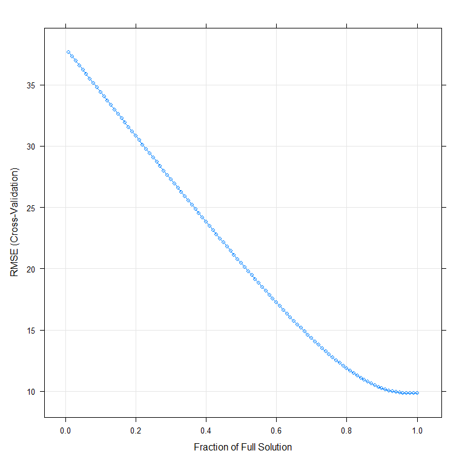

```r
plot(lasso_tune)
```

Indeed, the best tune is with fraction 0.99. Now it is time to predict on the testing set:

```r
test_results$lasso <- predict(lasso_tune, PassengersTest)
postResample(pred = test_results$lasso,  obs = test_results$Departure.Delay.in.Minutes)
```

```
##       RMSE   Rsquared        MAE
## 10.0987266  0.9303033  5.1678629
```

In this case, the value of 0.9303033 is obtained.

## 6.3 Conclusions about regression.

Once several methods have been applied to predict the chosen numerical variable (‘Departure.Delay.in.Minutes’), it is time to end the regression part and move on.

As observed in the results obtained above, several model were used in the prediction of the variable ‘Departure.Delay.in.Minutes’, all the way from a simple linear regression model to a lasso.

It looks as though all the models show very good results, but, to be precise, it was Lasso regression the one that helped us obtain better outcomes, with a value of R-Squared of 0.9303033. This result is curious, but easy to interpret. Lasso tends to obtain better results in comparison to other models. Even so, in this case, Lasso regression performed better because there are a small number of significant parameters and the others are close to zero or, in other words, only a few predictors actually influence the response.

# 7 Overall conclusion.

After all the work that has been exposed above, it is time to provide a wrap-up about the most important aspects discussed, as well as what was the best model.

Due to the extent of this dataset, I was not able to perform new methods that would have taught me more about machine learning (like K-NN). Conversely, it is a fact that better outcomes could have been obtained with them.

# 8 Bibliography.

[1]IBM, “What is Supervised Learning?,” www.ibm.com, Aug. 19, 2020. https://www.ibm.com/cloud/learn/supervised-learning

[2]A. Kumar, “Python - Replace Missing Values with Mean, Median & Mode,” Data Analytics, Oct. 03, 2021. https://vitalflux.com/pandas-impute-missing-values-mean-median-mode/#How_to_decide_which_imputation_technique_to_use (accessed Dec. 03, 2022).

[3]P. Patil, “What is Exploratory Data Analysis?,” Towards Data Science, Mar. 23, 2018. https://towardsdatascience.com/exploratory-data-analysis-8fc1cb20fd15

[4]G. Mrukwa, “Supervised and Unsupervised Machine Learning - Types of ML,” www.netguru.com, Oct. 08, 2018. https://www.netguru.com/blog/supervised-machine-learning

[5]“What is Logistic Regression?,” Statistics Solutions. https://www.statisticssolutions.com/free-resources/directory-of-statistical-analyses/what-is-logistic-regression/

[6]J. Brownlee, “A Gentle Introduction to the Bayes Optimal Classifier,” Machine Learning Mastery, Dec. 03, 2019. https://machinelearningmastery.com/bayes-optimal-classifier/

[7]R. Vickery, “8 Metrics to Measure Classification Performance,” Medium, Dec. 08, 2021. https://towardsdatascience.com/8-metrics-to-measure-classification-performance-984d9d7fd7aa

[8]G. Choueiry, “Understand Best Subset Selection – Quantifying Health,” Quantifying Health. https://quantifyinghealth.com/best-subset-selection/

[9]CFI Team, “Adjusted R-squared,” Corporate Finance Institute, Nov. 03, 2022. https://corporatefinanceinstitute.com/resources/data-science/adjusted-r-squared/#:~:text=Compared%20to%20a%20model%20with